# Modelagem

#### 6.1.4. Comparação de gaps DEA cross-section

Este gráfico mostra o **alvo** de produção (o `GAP_RESULTADO`) para os municípios *ineficientes*, comparando o alvo do SIOPE vs SICONFI. Municípios eficientes (score=1) não estão neste gráfico, pois seu “alvo” é a sua produção atual.

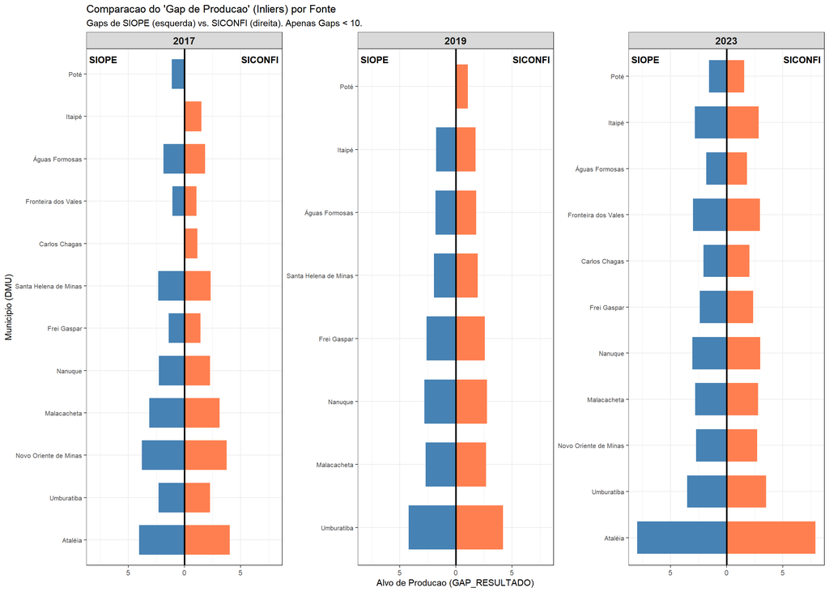

```r
# --- ETAPA 1: Identificar e filtrar outliers ---
dados_gap <- dados_eff %>%
  filter(is_efficient == "Ineficiente (Score > 1)")

limite_gap <- 10

outlier_pairs <- dados_gap %>%
  filter(GAP_RESULTADO > limite_gap) %>%
  select(DMU, ANO) %>%
  distinct()

dados_gap_inliers <- dados_gap %>%
  anti_join(outlier_pairs, by = c("DMU", "ANO"))

# --- ETAPA 2: Preparar dados para o gráfico de pirâmide ---
dados_pyramid <- dados_gap_inliers %>%
  mutate(
    Plot_Gap = ifelse(FONTE == "SIOPE", -GAP_RESULTADO, GAP_RESULTADO)
  )

# --- ETAPA 3: Plotar o Gráfico de Pirâmide ---
ggplot(dados_pyramid,
       # --- MUDANÇA 1: Reverter a ordem do eixo Y ---
       aes(x = Plot_Gap, y = fct_rev(fct_reorder(DMU, GAP_RESULTADO)), fill = FONTE)) +

  # --- MUDANÇA 2: Adicionar 'width' para afinar as barras ---
  geom_col(show.legend = FALSE, width = 0.7) +

  geom_vline(xintercept = 0, color = "black", linewidth = 1) +
  facet_wrap(~ ANO, ncol = 3, scales = "free_y") +
  scale_x_continuous(labels = ~ abs(.)) +
  scale_fill_manual(values = c("SIOPE" = "steelblue", "SICONFI" = "coral")) +

  geom_text(
    data = . %>% distinct(ANO, FONTE),
    aes(
      x = ifelse(FONTE == "SIOPE", -Inf, Inf),
      y = Inf,
      label = FONTE,
      hjust = ifelse(FONTE == "SIOPE", -0.1, 1.1)
    ),
    color = "black",
    vjust = 2,
    size = 4,
    fontface = "bold"
  ) +

  # Rótulos
  labs(
    title = "Comparacao do 'Gap de Producao' (Inliers) por Fonte",
    subtitle = "Gaps de SIOPE (esquerda) vs. SICONFI (direita). Apenas Gaps < 10.",
    x = "Alvo de Producao (GAP_RESULTADO)",
    y = "Municipio (DMU)"
  ) +
  theme_bw() +
  theme(
    legend.position = "none",
    strip.text = element_text(face = "bold", size = 12),
    axis.text.y = element_text(size = 8)
  )
```

#### 6.1.5. “Disputa” de benchmarks - 2023

Este gráfico mostra o principal benchmark para cada DMU em 2023.

```r
dados_bench_raw <- readxl::read_excel("dados_mucuri.xlsx", sheet = "benchmarks")

# 2. Preparar dados para o HEATMAP (dados_bench_long)
dados_bench_long <- dados_bench_raw %>%
  rename(Influencia = LAMBDA) %>%
  filter(DMU != BENCHMARK, Influencia > 0) %>%
  mutate(
    DMU = factor(DMU),
    BENCHMARK = factor(BENCHMARK),
    FONTE = factor(FONTE)
  )

kable(head(dados_bench_long), caption = "Amostra dos Dados de Benchmark Prontos")
```

Amostra dos Dados de Benchmark Prontos

| DMU | BENCHMARK | FONTE | Influencia |
| --- | --- | --- | --- |
| Águas Formosas | Santa Helena de Minas | SIOPE | 1.0000 |
| Ataléia | Santa Helena de Minas | SIOPE | 0.7112 |
| Carlos Chagas | Santa Helena de Minas | SIOPE | 0.4296 |
| Frei Gaspar | Santa Helena de Minas | SIOPE | 0.8243 |
| Fronteira dos Vales | Santa Helena de Minas | SIOPE | 1.0000 |
| Itaipé | Santa Helena de Minas | SIOPE | 0.2530 |

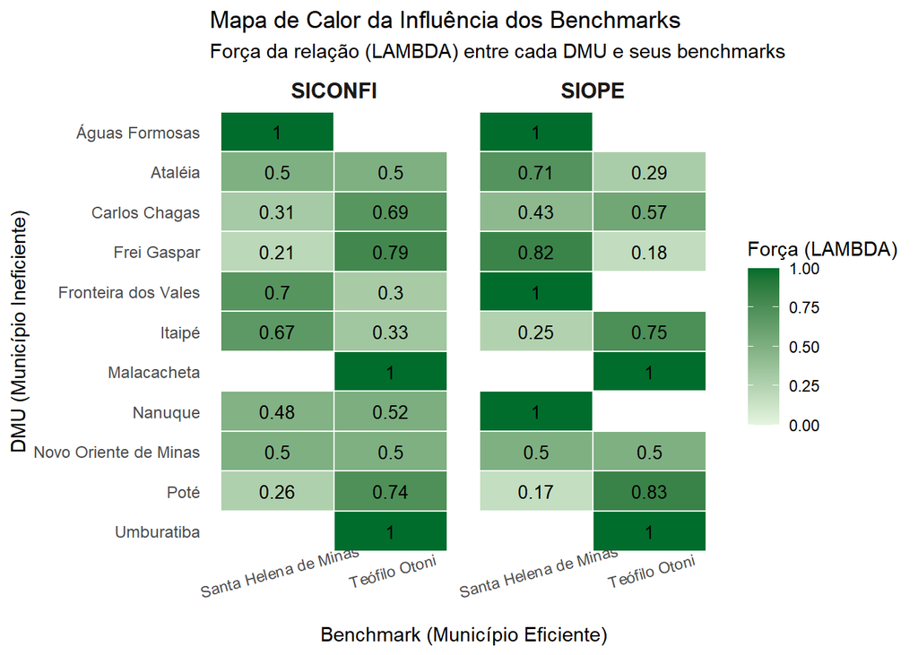

```r
# 3. Preparar dados para o GRAFICO DE REDE (graph_obj)
# Esta é a forma mais robusta de criar o objeto de grafo

# 3a. Criar a lista de ARESTAS (edges)
dados_edges <- dados_bench_raw %>%
  rename(Influencia = LAMBDA) %>%
  filter(DMU != BENCHMARK, Influencia > 0) %>%
  mutate(FONTE = factor(FONTE))

# 3b. Criar a lista de NÓS (nodes)
all_nodes_names <- unique(c(dados_edges$DMU, dados_edges$BENCHMARK))
nodes_df <- data.frame(name = all_nodes_names) %>%
  mutate(
    is_benchmark = (name %in% c("Santa Helena de Minas", "Teófilo Otoni"))
  )

# 3c. Criar o objeto de grafo (graph_obj) - CORRIGIDO
# Primeiro, criamos o grafo a partir das ARESTAS (edges) usando as_tbl_graph()
graph_obj <- as_tbl_graph(
  dados_edges,
  from = "BENCHMARK",
  to = "DMU",
  directed = TRUE
)

# Segundo, juntamos (join) os atributos dos NÓS (nodes)
graph_obj <- graph_obj %>%
  activate(nodes) %>% # Foca na tabela de nós
  # O 'name' é criado automaticamente pelo as_tbl_graph
  left_join(nodes_df, by = "name")

# Este gráfico usa o 'dados_bench_long' e permanece o mesmo
ggplot(dados_bench_long, aes(x = BENCHMARK, y = fct_rev(DMU), fill = Influencia)) +

  geom_tile(color = "white", linewidth = 0.5) +
  geom_text(aes(label = round(Influencia, 2)), color = "black", size = 3.5) +
  facet_wrap(~ FONTE, ncol = 2) +
  scale_fill_gradient(low = "#e6f5e0", high = "#006d2c", limits = c(0, 1)) +

  labs(
    title = "Mapa de Calor da Influência dos Benchmarks",
    subtitle = "Força da relação (LAMBDA) entre cada DMU e seus benchmarks",
    x = "Benchmark (Município Eficiente)",
    y = "DMU (Município Ineficiente)",
    fill = "Força (LAMBDA)"
  ) +
  theme_minimal() +
  theme(
    axis.text.x = element_text(angle = 15, hjust = 0.5),
    axis.text.y = element_text(size = 9),
    strip.text = element_text(face = "bold", size = 12),
    panel.grid = element_blank()
  )
```

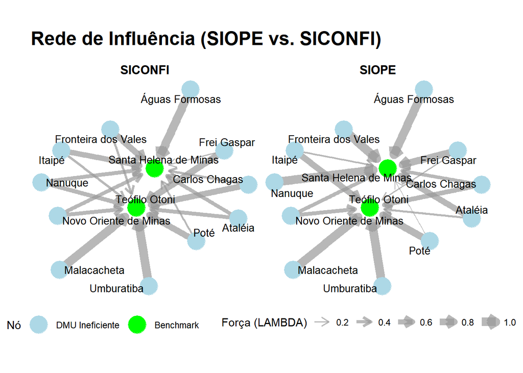

```r
# Este gráfico usa o 'graph_obj' (que agora está correto)
ggraph(graph_obj, layout = 'kk') +

  # --- AS SETAS (EDGES) ---
  facet_edges(~ FONTE) +
  geom_edge_link(
    aes(width = Influencia),
    color = "grey60",
    alpha = 0.7,
    arrow = arrow(length = unit(3, 'mm')),
    end_cap = circle(5, 'mm')
  ) +

  # --- OS NÓS (MUNICÍPIOS) ---
  # 'is_benchmark' foi juntado (joined) no bloco 'dados-benchmark'
  geom_node_point(
    aes(color = is_benchmark),
    size = 8
  ) +

  # 'name' é a coluna padrão de nomes dos nós
  geom_node_text(aes(label = name), repel = TRUE, size = 3.5, color = "black") +

  # --- Legendas e Escalas ---
  scale_edge_width(name = "Força (LAMBDA)", range = c(0.5, 4)) +

  scale_color_manual(
    name = "Nó",
    values = c("TRUE" = "green", "FALSE" = "lightblue"),
    labels = c("TRUE" = "Benchmark", "FALSE" = "DMU Ineficiente")
  ) +

  labs(
    title = "Rede de Influência (SIOPE vs. SICONFI)",
  ) +
  theme_graph() +
  theme(
    legend.position = "bottom",
    strip.text = element_text(face = "bold", size = 12)
  )
```

### 6.2. Índice de Malmquist (Produtividade)

Calculamos o índice de Malmquist para avaliar a mudança na produtividade total dos fatores (TFP) ao longo do tempo. Primeiro, carregamos os dados preparados para esta análise.

#### 6.2.1. Malmquist - SIOPE

```r
dea_malmquist_siope <- make_malmquist(dados_dea,
                                    percol = 2,
                                    nper = 3,
                                    arrangement = "vertical",
                                    input = 3, #coluna 3 -> SIOPE
                                    output = 5:6)

modelo_malmquist_siope <- malmquist_index( dea_malmquist_siope,
                                         orientation = "oo",
                                         rts = "vrs")

# Exporta resultados para Excel
summary(modelo_malmquist_siope)
```

```
## $Results
##    Period                   DMU           mi        tc         pech      sech
## 1    2019        Águas Formosas 1.096573e+00 1.0253384 1.017100e+00 1.0514931
## 2    2019               Ataléia 9.055989e-04 0.9585478 1.133484e-03 0.8335021
## 3    2019         Carlos Chagas 7.800444e-01 1.0253384 1.000000e+00 0.7607677
## 4    2019           Frei Gaspar 4.834468e-01 1.0253384 5.434364e-01 0.8676265
## 5    2019   Fronteira dos Vales 2.829363e-04 0.9913808 3.030899e-04 0.9416223
## 6    2019                Itaipé 7.339308e-01 1.0253384 5.686485e-01 1.2587631
## 7    2019           Malacacheta 1.270840e+00 1.0253384 1.160446e+00 1.0680675
## 8    2019               Nanuque 8.545713e-01 0.9913808 8.171917e-01 1.0548333
## 9    2019 Novo Oriente de Minas 9.039726e-04 0.9913808 1.060496e-03 0.8598161
## 10   2019                  Poté 1.299678e+00 1.0253384 1.111070e+00 1.1408459
## 11   2019 Santa Helena de Minas 1.046039e+00 1.0253384 1.192341e+00 0.8556192
## 12   2019         Teófilo Otoni 9.913808e-01 0.9913808 1.000000e+00 1.0000000
## 13   2019            Umburatiba 4.443975e-01 1.0253384 5.456751e-01 0.7942738
```

[output cut: 34 more lines]

#### 6.2.2. Malmquist - SICONFI

```r
dea_malmquist_siconfi <- make_malmquist(dados_dea,
                                        percol = 2,
                                        nper = 3,
                                        arrangement = "vertical",
                                        input = 4, #coluna 4 -> SICONFI
                                        output = 5:6)

modelo_malmquist_siconfi <- malmquist_index( dea_malmquist_siconfi,
                                             orientation = "oo",
                                             rts = "vrs")

# Exporta resultados para Excel
summary(modelo_malmquist_siconfi)
```

```
## $Results
##    Period                   DMU           mi        tc         pech      sech
## 1    2019        Águas Formosas 6.832679e-01 0.7366200 1.017100e+00 0.9119765
## 2    2019               Ataléia 7.538478e-04 0.6886365 1.133484e-03 0.9657800
## 3    2019         Carlos Chagas 5.975875e-01 0.7366200 1.076227e+00 0.7537966
## 4    2019           Frei Gaspar 3.343971e-01 0.7366200 5.569750e-01 0.8150483
## 5    2019   Fronteira dos Vales 1.944205e-04 0.7122243 3.030899e-04 0.9006454
## 6    2019                Itaipé 5.912124e-01 0.7366200 8.646726e-01 0.9282145
## 7    2019           Malacacheta 8.071000e-01 0.7366200 1.160446e+00 0.9441885
## 8    2019               Nanuque 5.534585e-01 0.7122243 8.171917e-01 0.9509208
## 9    2019 Novo Oriente de Minas 6.827508e-04 0.7122243 1.060496e-03 0.9039330
## 10   2019                  Poté 8.772698e-01 0.7366200 9.341189e-01 1.2749334
## 11   2019 Santa Helena de Minas 6.968811e-01 0.7366200 1.192341e+00 0.7934414
## 12   2019         Teófilo Otoni 7.122243e-01 0.7122243 1.000000e+00 1.0000000
## 13   2019            Umburatiba 3.480200e-01 0.7366200 5.456751e-01 0.8658180
```

[output cut: 34 more lines]

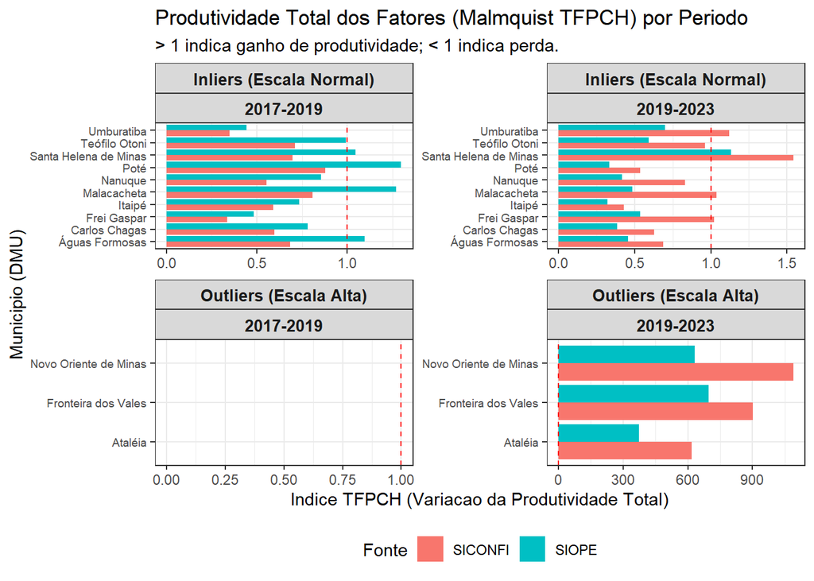

```r
# Extrai os resultados POR PERÍODO
# t() transpõe a matriz para que as DMUs fiquem nas linhas
malm_siope_df <- as.data.frame(t(modelo_malmquist_siope$mi))
# Renomeia as colunas com os períodos
colnames(malm_siope_df) <- c("2017-2019", "2019-2023")

malm_siope_df <- malm_siope_df %>%
  rownames_to_column("DMU") %>% # Pega o nome das DMUs (que eram nomes de linha)
  # Transforma de formato "wide" para "long", ideal para o ggplot
  pivot_longer(cols = -DMU, names_to = "Periodo", values_to = "TFPCH") %>%
  mutate(Fonte = "SIOPE")

# Extrai os resultados POR PERÍODO
malm_siconfi_df <- as.data.frame(t(modelo_malmquist_siconfi$mi))
colnames(malm_siconfi_df) <- c("2017-2019", "2019-2023")

malm_siconfi_df <- malm_siconfi_df %>%
  rownames_to_column("DMU") %>%
  pivot_longer(cols = -DMU, names_to = "Periodo", values_to = "TFPCH") %>%
  mutate(Fonte = "SICONFI")

# ----- GRÁFICO 4: COMPARAÇÃO DO ÍNDICE DE MALMQUIST (TFPCH) POR PERÍODO -----

# Combina os resultados
malm_combinado_df <- bind_rows(malm_siope_df, malm_siconfi_df)

# --- DEFINIÇÃO DE GRUPOS (POR LINHA) ---
# Esta é a parte crucial: A classificação "Grupo" é aplicada a CADA LINHA.
# Um município pode ser "Inlier" em um período e "Outlier" em outro.
malm_combinado_df <- malm_combinado_df %>%
  mutate(
    Grupo = ifelse(TFPCH > 2 | TFPCH < 0.2,
                   "Outliers (Escala Alta)",
                   "Inliers (Escala Normal)")
  )

# --- NOVO GRÁFICO COM 4 PAINÉIS (usando facet_wrap) ---
# Trocamos facet_grid por facet_wrap e removemos o fct_reorder
ggplot(malm_combinado_df, aes(x = TFPCH, y = DMU, fill = Fonte)) +
  geom_col(position = position_dodge(width = 0.9)) +
  geom_vline(xintercept = 1, linetype = "dashed", color = "red") +

  # --- MUDANÇA PARA facet_wrap ---
  # Isso cria 4 painéis independentes. "scales = 'free'" permite que cada
  # painel tenha seus próprios eixos X e Y (removendo DMUs vazias).
  facet_wrap(Grupo ~ Periodo, scales = "free", ncol = 2) +

  labs(
    title = "Produtividade Total dos Fatores (Malmquist TFPCH) por Periodo",
    subtitle = "> 1 indica ganho de produtividade; < 1 indica perda.",
    x = "Indice TFPCH (Variacao da Produtividade Total)",
    y = "Municipio (DMU)"
  ) +
  theme_bw() +
  theme(legend.position = "bottom",
        # Texto do eixo Y menor para caber
        axis.text.y = element_text(size = 7),
        strip.text = element_text(face = "bold", size = 10))
```

```r
# Carrega os dados da planilha
dados_malm_raw <- readxl::read_excel("dados_mucuri.xlsx", sheet = "avg_mlmq")

# Pivota os dados: transforma as colunas (mi, tc, pech, sech) em linhas
dados_malm_long <- dados_malm_raw %>%
  pivot_longer(
    cols = c("mi", "tc", "pech", "sech"),
    names_to = "Componente",
    values_to = "Valor"
  ) %>%
  # Converte 'Componente' em um fator para ordenar as barras no gráfico
  mutate(
    Componente = factor(Componente, levels = c("mi", "tc", "pech", "sech")),
    ANO = factor(ANO) # Converte ANO em fator para o eixo X
  )

kable(head(dados_malm_long), caption = "Dados de Malmquist em Formato Longo")
```

Dados de Malmquist em Formato Longo

| ANO | FONTE | Componente | Valor |
| --- | --- | --- | --- |
| 2019 | SIOPE | mi | 0.1601876 |
| 2019 | SIOPE | tc | 1.0095235 |
| 2019 | SIOPE | pech | 0.1669871 |
| 2019 | SIOPE | sech | 0.9502319 |
| 2023 | SIOPE | mi | 2.5126223 |
| 2023 | SIOPE | tc | 0.5776053 |

O gráfico abaixo mostra o índice `mi` (azul) e seus três componentes. A linha vermelha tracejada em `Y=1` representa a fronteira de “sem mudança”. Valores acima de 1 são ganhos de produtividade/eficiência; valores abaixo são perdas.

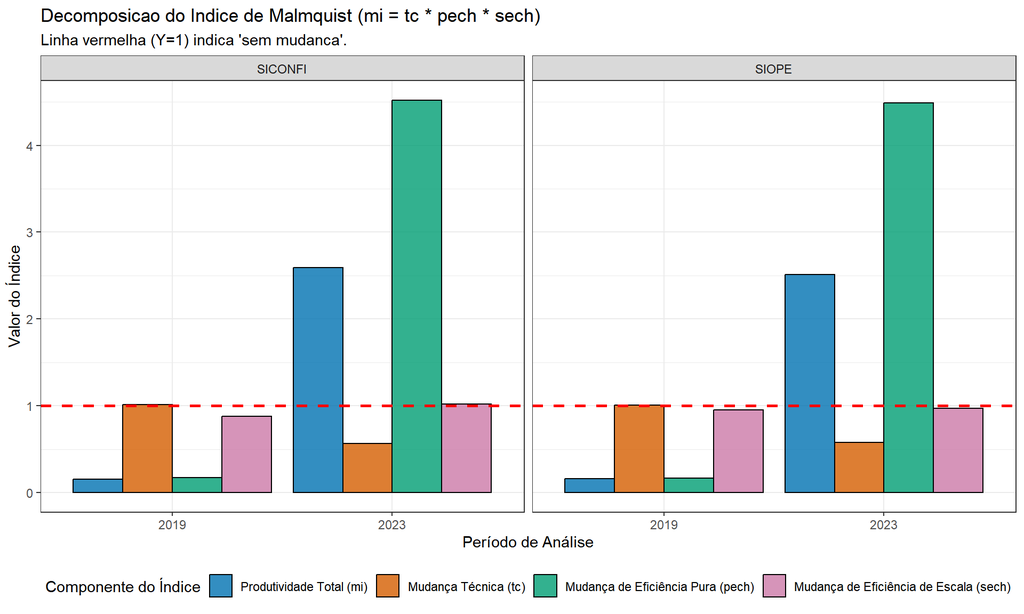

```r
ggplot(dados_malm_long, aes(x = ANO, y = Valor, fill = Componente)) +

  # Cria as barras agrupadas (lado a lado)
  geom_col(position = position_dodge(width = 0.9), color = "black", alpha = 0.8) +

  # --- A LINHA DE REFERÊNCIA (CRUCIAL) ---
  # y=1 significa "sem mudança"
  geom_hline(yintercept = 1, linetype = "dashed", color = "red", linewidth = 1) +

  # --- Faceta por Fonte ---
  # Um painel para SIOPE, outro para SICONFI
  facet_wrap(~ FONTE, ncol = 2) +

  # Define cores personalizadas para os componentes
  scale_fill_manual(
    values = c("mi" = "#0072B2", "tc" = "#D55E00", "pech" = "#009E73", "sech" = "#CC79A7"),
    labels = c("mi" = "Produtividade Total (mi)",
               "tc" = "Mudança Técnica (tc)",
               "pech" = "Mudança de Eficiência Pura (pech)",
               "sech" = "Mudança de Eficiência de Escala (sech)")
  ) +

  # Rótulos (sem acentos para evitar erros de codificação)
  labs(
    title = "Decomposicao do Indice de Malmquist (mi = tc * pech * sech)",
    subtitle = "Linha vermelha (Y=1) indica 'sem mudanca'.",
    x = "Período de Análise",
    y = "Valor do Índice",
    fill = "Componente do Índice"
  ) +
  theme_bw() +
  theme(legend.position = "bottom")
```

O gráfico abaixo mostra a mudança em cada componente (mi, tc, pech, sech) entre 2019 e 2023. A linha vermelha tracejada em `Y=1` representa a fronteira de “sem mudança”.

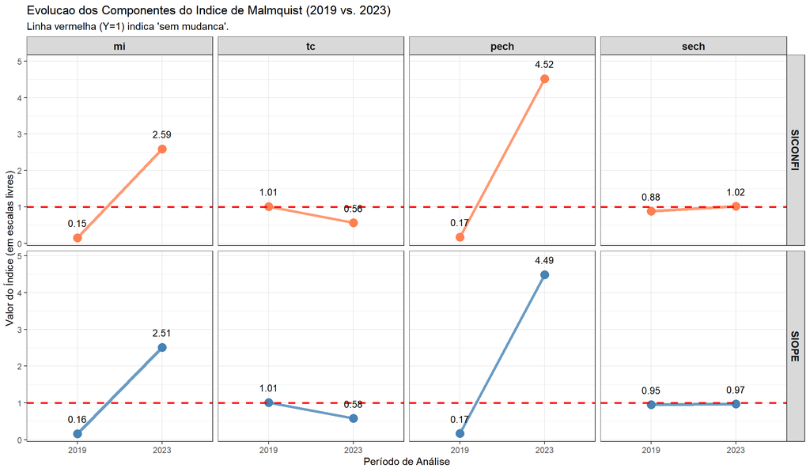

```r
# O objeto 'dados_malm_long' foi criado no bloco 'carregar-dados-malmquist'

ggplot(dados_malm_long, aes(x = ANO, y = Valor, group = FONTE, color = FONTE)) +

  # A linha de inclinação
  geom_line(linewidth = 1.5, alpha = 0.8) +

  # Os pontos de início e fim
  geom_point(size = 4) +

  # Linha de referência Y=1
  geom_hline(yintercept = 1, linetype = "dashed", color = "red", linewidth = 1) +

  # --- MUDANÇA 1: Voltar para o facet_grid (8 painéis) ---
  # 'scales = "free_y"' permite que 'pech' tenha sua própria escala
  facet_grid(FONTE ~ Componente, scales = "free_y") +

  # --- MUDANÇA 2: Usar geom_text para os rótulos ---
  geom_text(
    aes(label = round(Valor, 2)),
    color = "black",
    size = 3.5,
    show.legend = FALSE,
    vjust = -1.5 # Posição vertical (um pouco acima do ponto)
  ) +

  # --- MUDANÇA 3: Expandir o eixo Y para mostrar os rótulos ---
  # Adiciona 15% de espaço no topo de CADA painel
  scale_y_continuous(expand = expansion(mult = c(0.05, 0.15))) +

  # Define as cores SIOPE/SICONFI
  scale_color_manual(values = c("SIOPE" = "steelblue", "SICONFI" = "coral")) +

  # Rótulos (sem acentos)
  labs(
    title = "Evolucao dos Componentes do Indice de Malmquist (2019 vs. 2023)",
    subtitle = "Linha vermelha (Y=1) indica 'sem mudanca'.",
    x = "Período de Análise",
    y = "Valor do Índice (em escalas livres)",
    color = "Fonte de Dados"
  ) +
  theme_bw() +
  theme(
    legend.position = "none", # Legenda é redundante (está no título da linha)
    strip.text = element_text(face = "bold", size = 11)
  )
```

### 6.3. Carga e Preparação dos Dados (Nível DMU)

Carregamos os dados da planilha “dmus_mlmq” e os preparamos para a visualização, pivotando os componentes (mi, tc, pech, sech) para o formato “longo”.

```r
# 1. Carregar os dados
dados_mlmq_dmu_raw <- readxl::read_excel("dados_mucuri.xlsx", sheet = "dmus_mlmq")

# 2. Pivotar para o formato longo (Tidy)
dados_mlmq_dmu_long <- dados_mlmq_dmu_raw %>%
  pivot_longer(
    cols = c("mi", "tc", "pech", "sech"),
    names_to = "Componente",
    values_to = "Valor"
  ) %>%
  # 3. Converter colunas para Fatores (para ordenar os gráficos)
  mutate(
    Componente = factor(Componente, levels = c("mi", "tc", "pech", "sech")),
    ANO = factor(ANO), # ANO precisa ser fator para o eixo X do slope chart
    DMU = factor(DMU),
    FONTE = factor(FONTE)
  )

kable(head(dados_mlmq_dmu_long), caption = "Amostra dos Dados Malmquist por DMU (Formato Longo)")
```

Amostra dos Dados Malmquist por DMU (Formato Longo)

| ANO | FONTE | DMU | Componente | Valor |
| --- | --- | --- | --- | --- |
| 2019 | SIOPE | Águas Formosas | mi | 1.0965728 |
| 2019 | SIOPE | Águas Formosas | tc | 1.0253384 |
| 2019 | SIOPE | Águas Formosas | pech | 1.0171004 |
| 2019 | SIOPE | Águas Formosas | sech | 1.0514931 |
| 2019 | SIOPE | Ataléia | mi | 0.0009056 |
| 2019 | SIOPE | Ataléia | tc | 0.9585478 |

#### 6.3.1. Gráfico: Matriz de Análise Malmquist (13 DMUs x 4 Componentes)

O gráfico abaixo é uma matriz completa que mostra a evolução de 2019 para 2023 de todos os componentes, para todos os municípios.

- **Linhas:** Municípios (DMUs)
- **Colunas:** Componentes (`mi`, `tc`, `pech`, `sech`)
- **Cores:** Linha azul (SIOPE) vs. Linha vermelha (SICONFI)
- **Linha Tracejada:** Referência de “sem mudança” (Valor = 1.0)

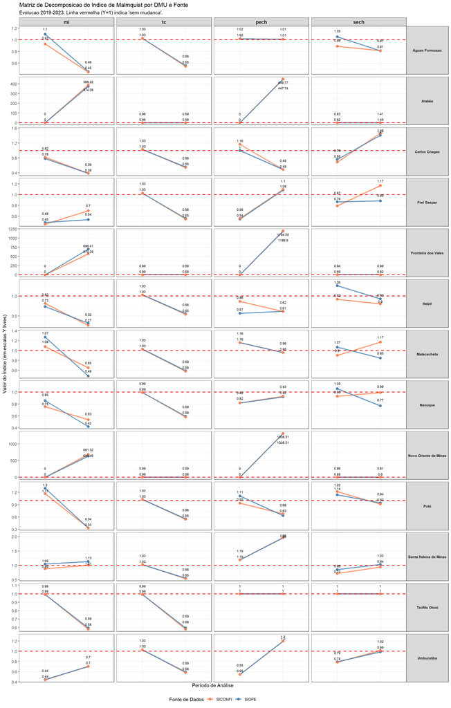

```r
ggplot(dados_mlmq_dmu_long, aes(x = ANO, y = Valor, group = FONTE, color = FONTE)) +

  # A linha de inclinação (que conecta 2019 a 2023)
  geom_line(linewidth = 1.2, alpha = 0.8) +

  # Os pontos de início e fim
  geom_point(size = 2.5) +

  # --- A LINHA DE REFERÊNCIA (CRUCIAL) ---
  geom_hline(yintercept = 1, linetype = "dashed", color = "red", linewidth = 0.8) +

  # --- A MÁGICA: Faceta de Grade (13 Linhas x 4 Colunas) ---
  # 'scales = "free_y"' é ESSENCIAL: permite que cada linha (DMU)
  # e cada coluna (Componente) tenha sua própria escala de eixo Y.
  # Isso impede que os outliers (ex: 'pech' em Ataléia) esmaguem os outros.
  facet_grid(DMU ~ Componente, scales = "free_y") +

  # --- Rótulos dos Valores ---
  # Usamos ggrepel para evitar que os rótulos de SIOPE/SICONFI se sobreponham
  geom_text_repel(
    aes(label = round(Valor, 2)),
    color = "black",
    size = 2.5, # Tamanho de fonte menor para caber
    show.legend = FALSE,
    # Força os rótulos a se afastarem verticalmente
    direction = "y",
    nudge_y = 0.1,
    segment.color = NA
  ) +

  # Define as cores SIOPE/SICONFI
  scale_color_manual(values = c("SIOPE" = "steelblue", "SICONFI" = "coral")) +

  # Rótulos (sem acentos)
  labs(
    title = "Matriz de Decomposicao do Indice de Malmquist por DMU e Fonte",
    subtitle = "Evolucao 2019-2023. Linha vermelha (Y=1) indica 'sem mudanca'.",
    x = "Período de Análise",
    y = "Valor do Índice (em escalas Y livres)",
    color = "Fonte de Dados"
  ) +
  theme_bw() +
  theme(
    legend.position = "bottom",
    # Títulos dos painéis (DMU e Componente) em negrito e com tamanho ajustado
    strip.text.x = element_text(face = "bold", size = 11),
    strip.text.y = element_text(face = "bold", size = 8, angle = 0),
    # Remove o texto do eixo X (é repetitivo)
    axis.text.x = element_blank(),
    axis.ticks.x = element_blank()
  )
```

## 7. Análise de Caso: Municípios Outliers

Esta seção isola esses três municípios para uma análise focada.

### 7.1. Carga e Filtro dos Dados dos Outliers

Primeiro, carregamos os pacotes necessários e filtramos a planilha `malmquist_data` para conter *apenas* os três municípios de interesse.

```r
# 1. Carregar os dados
dados_outliers_raw <- readxl::read_excel("dados_mucuri.xlsx", sheet = "malmquist_data")

# 2. Definir a lista de outliers e filtrar
lista_outliers <- c("Ataléia", "Fronteira dos Vales", "Novo Oriente de Minas")

dados_outliers <- dados_outliers_raw %>%
  filter(nom_munic %in% lista_outliers)

kable(head(dados_outliers), caption = "Amostra dos Dados dos 3 Outliers")
```

Amostra dos Dados dos 3 Outliers

| nom_munic | ano | gasto_med_3A_SIOPE | gasto_med_3A_SICONFI | lp_adequado | mt_adequado |
| --- | --- | --- | --- | --- | --- |
| Ataléia | 2017 | 0.9118263 | 1.1180586 | 0.0909 | 0.0909 |
| Fronteira dos Vales | 2017 | 0.7970510 | 0.6220570 | 0.5000 | 0.1000 |
| Novo Oriente de Minas | 2017 | 0.6346353 | 0.6849203 | 0.1429 | 0.0001 |
| Ataléia | 2019 | 1.1076750 | 1.6316124 | 0.0001 | 0.0001 |
| Fronteira dos Vales | 2019 | 0.8570700 | 0.9734350 | 0.0001 | 0.0001 |
| Novo Oriente de Minas | 2019 | 0.7473527 | 1.0679095 | 0.0001 | 0.0001 |

### 7.2. Gráfico 1: Séries Temporais de Gastos vs. Resultados

A forma mais clara de ver a história é plotar os “Inputs” (Gastos) e os “Outputs” (Taxas) em gráficos separados, mas alinhados pelo tempo.

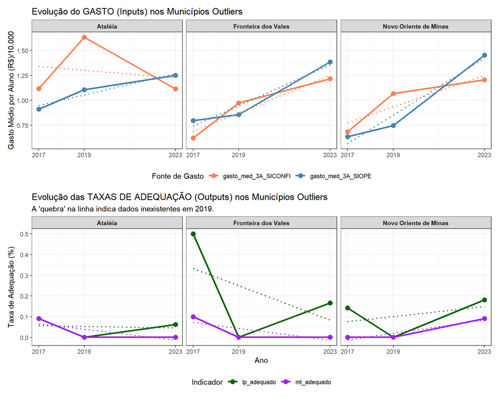

```r
# 1. Preparar dados de Gasto (longo)
dados_outliers_gasto_long <- dados_outliers %>%
  pivot_longer(
    cols = c("gasto_med_3A_SIOPE", "gasto_med_3A_SICONFI"),
    names_to = "Fonte_Gasto",
    values_to = "Gasto"
  )

# 2. Preparar dados de Taxas (longo)
dados_outliers_taxas_long <- dados_outliers %>%
  pivot_longer(
    cols = c("lp_adequado", "mt_adequado"),
    names_to = "Tipo_Taxa",
    values_to = "Taxa"
  )

# 3. Gráfico A: Gastos (Inputs)
plot_gasto <- ggplot(dados_outliers_gasto_long,
                     aes(x = ano, y = Gasto, color = Fonte_Gasto)) +
  geom_line(linewidth = 1.2) +
  geom_point(size = 3) +
  geom_smooth(method = "lm", se = FALSE, linetype = "dotted", linewidth = 0.8) +
  facet_wrap(~ nom_munic, ncol = 3) + # Um painel por município
  scale_x_continuous(breaks = c(2017, 2019, 2023)) +
  scale_color_manual(values = c("gasto_med_3A_SIOPE" = "steelblue", "gasto_med_3A_SICONFI" = "coral")) +
  labs(
    title = "Evolução do GASTO (Inputs) nos Municípios Outliers",
    x = NULL, # Remove o eixo X para alinhar com o gráfico de baixo
    y = "Gasto Médio por Aluno (R$)/10.000",
    color = "Fonte de Gasto"
  ) +
  theme_bw() +
  theme(legend.position = "bottom",
        strip.text = element_text(face = "bold"))

# 4. Gráfico B: Taxas (Outputs)
plot_taxas <- ggplot(dados_outliers_taxas_long,
                     aes(x = ano, y = Taxa, color = Tipo_Taxa)) +
  geom_line(linewidth = 1.2) + # A linha irá quebrar em 2019 (onde há NA)
  geom_point(size = 3) +
  geom_smooth(method = "lm", se = FALSE, linetype = "dotted", linewidth = 0.8) +
  facet_wrap(~ nom_munic, ncol = 3) +
  scale_x_continuous(breaks = c(2017, 2019, 2023)) +
  scale_color_manual(values = c("lp_adequado" = "darkgreen", "mt_adequado" = "purple")) +
  labs(
    title = "Evolução das TAXAS DE ADEQUAÇÃO (Outputs) nos Municípios Outliers",
    subtitle = "A 'quebra' na linha indica dados inexistentes em 2019.",
    x = "Ano",
    y = "Taxa de Adequação (%)",
    color = "Indicador"
  ) +
  theme_bw() +
  theme(legend.position = "bottom",
        strip.text = element_text(face = "bold"))

# 5. Combina os gráficos (um em cima do outro)
plot_gasto / plot_taxas
```

### 7.3. Gráfico 2: Relação Custo-Resultado (Scatter Plot Conectado)

Este gráfico (menos usual) mostra a trajetória da eficiência: o eixo X é o Gasto e o eixo Y é a Taxa de Adequação. Ele nos ajuda a ver se mais gasto está gerando melhores resultados ao longo do tempo.

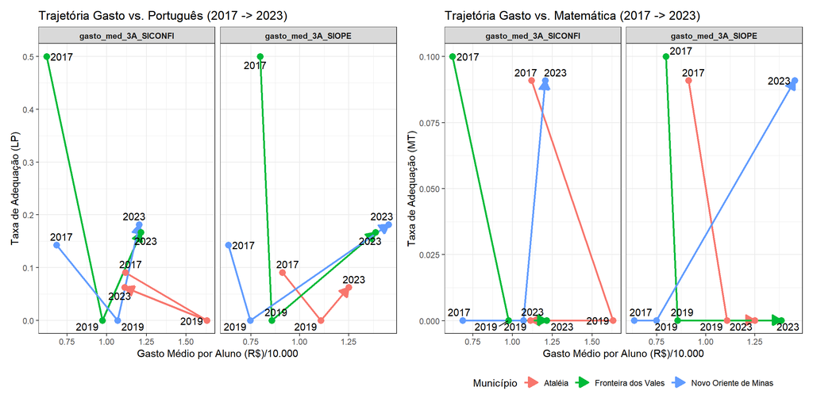

```r
# 1. Preparar os dados (pivotar gastos, manter taxas)
dados_outliers_scatter <- dados_outliers %>%
  pivot_longer(
    cols = c(gasto_med_3A_SIOPE, gasto_med_3A_SICONFI),
    names_to = "Fonte_Gasto",
    values_to = "Gasto"
  )

# 2. Gráfico A: Português
plot_lp <- ggplot(dados_outliers_scatter,
                  aes(x = Gasto, y = lp_adequado, color = nom_munic)) +
  # geom_path conecta os pontos na ordem do 'ano'
  geom_path(linewidth = 1, arrow = arrow(type = "closed", length = unit(0.15, "inches"))) +
  geom_point(size = 3) +
  # geom_text_repel rotula os anos (2017 e 2023)
  geom_text_repel(aes(label = ano), color = "black", show.legend = FALSE) +
  # Separa SIOPE e SICONFI
  facet_wrap(~ Fonte_Gasto, scales = "free_x") +
  labs(
    title = "Trajetória Gasto vs. Português (2017 -> 2023)",
    x = "Gasto Médio por Aluno (R$)/10.000",
    y = "Taxa de Adequação (LP)"
  ) +
  theme_bw() +
  theme(legend.position = "none",
        strip.text = element_text(face = "bold"))

# 3. Gráfico B: Matemática
plot_mt <- ggplot(dados_outliers_scatter,
                  aes(x = Gasto, y = mt_adequado, color = nom_munic)) +
  geom_path(linewidth = 1, arrow = arrow(type = "closed", length = unit(0.15, "inches"))) +
  geom_point(size = 3) +
  geom_text_repel(aes(label = ano), color = "black", show.legend = FALSE) +
  facet_wrap(~ Fonte_Gasto, scales = "free_x") +
  labs(
    title = "Trajetória Gasto vs. Matemática (2017 -> 2023)",
    x = "Gasto Médio por Aluno (R$)/10.000",
    y = "Taxa de Adequação (MT)",
    color = "Município" # Adiciona a legenda só aqui
  ) +
  theme_bw() +
  theme(legend.position = "bottom",
        strip.text = element_text(face = "bold"))

# 4. Combina os gráficos (lado a lado)
plot_lp + plot_mt
```